# Part II - (Exploration of Loan Data from Prosper)

## by (Kevin Egunza)

## Investigation Overview

## Dataset

> **Loan Data from Prosper**

### The structure of the dataset

> The prosperLoanData Dataset has 113,937 rows and 81 columns.

### The main feature of interest in the dataset

> `LoanOriginalAmount`
> - Are there differences between loans depending on how large the original loan amount was?

### Features in the dataset that will help support the investigation into the feature of interest

> `Term`, `LoanStatus`, `BorrowerRate`, `BorrowerState`, `EmploymentStatus`, `LoanOriginalAmount`, `CreditScoreRangeLower`, `DebtToIncomeRatio`, `IncomeRange`, `AmountDelinquent`, `AvailableBankcardCredit`

## Key Insights for Presentation

- The LoanOriginalAmount has a right skewed distribution with most loan amount between 2000 and 15000.
- In regards to the relation betweeen LoanOriginalAmount and BorrowerRate, loan Amounts of above 25000 all had BorrowerRate of below 0.2 compared to other lower loan amounts with BorrowerRate ranging from close to 0.0 upto 0.5.
- Considering the relation between LoanOriginalAmount and CreditScoreRangeLower, all loan Amounts of above 25000 associate with scores of 720 and above.
- Relating DebtToIncomeRatio to LoanOriginalAmount, we observe that all loan amounts above 25000 have low DebtToIncomeRatio of not more than 0.4 compared to other lower loan amounts. Most Loan amounts, regardless of the amount, have a DebtToIncomeRatio of between 0 and 1.
- Given that most loan amounts above 25,000 are current, only 2 were delinquent with 18,239 and 70,734.
- Compared to low amounts, LoanOriginalAmounts of above 25000 do not have AvailableBankcardCredit greater than 200,000.
- Considering the relation between LoanOriginalAmount and EmploymentStatus, loan amounts above 25000 were issued to the Employed, Full-time and other categories.
- Most loan amounts above `25,000` were issued to borrowers in the largest income-range category of `100,000+`.
- Borrowers of loans above `25,000` are in the `7`, `6` and `5` of ProsperRating (numeric) categories.

## (Visualization 1)

> - The LoanOriginalAmount has a right skewed distribution with most loan amount between 2000 and 15000.

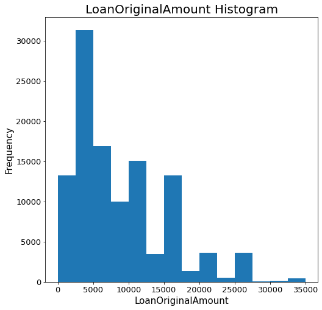

## (Visualization 2)

> - In regards to the relation betweeen LoanOriginalAmount and BorrowerRate, loan Amounts of above 25000 all had BorrowerRate of below 0.2 compared to other lower loan amounts with BorrowerRate ranging from close to 0.0 upto 0.5.

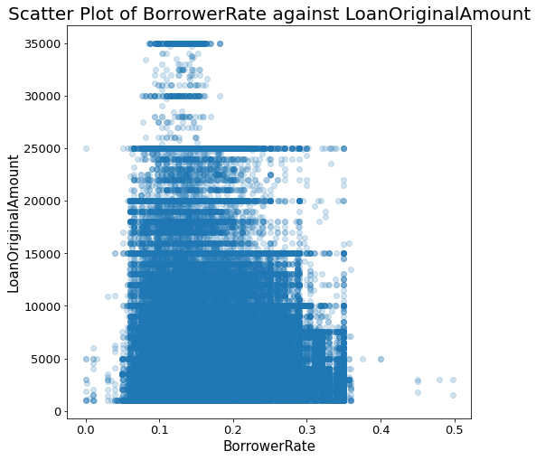

## (Visualization 3)

> - Considering the relation between LoanOriginalAmount and CreditScoreRangeLower, all loan Amounts of above 25000 associate with scores of 720 and above.

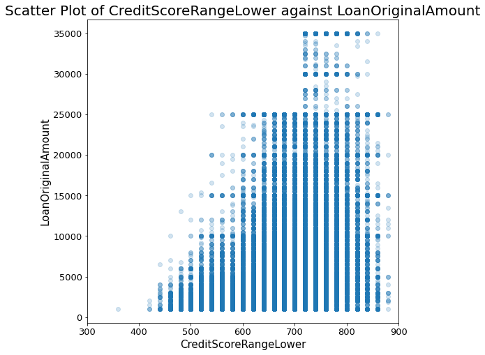

## (Visualization 4)

> - Relating DebtToIncomeRatio to LoanOriginalAmount, we observe that all loan amounts above 25000 have low DebtToIncomeRatio of not more than 0.4 compared to other lower loan amounts. Most Loan amounts, regardless of the amount, have a DebtToIncomeRatio of between 0 and 1.

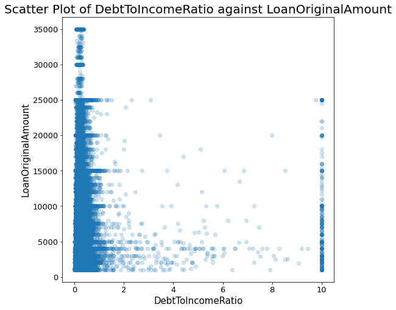

## (Visualization 5)

> - Given that most loan amounts above 25,000 are current, only 2 were delinquent with 18,239 and 70,734.

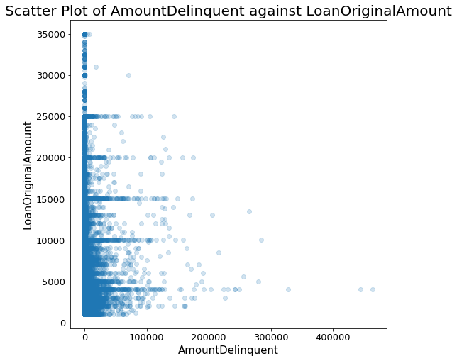

## (Visualization 6)

> - Compared to low amounts, LoanOriginalAmounts of above 25000 do not have AvailableBankcardCredit greater than 200,000.

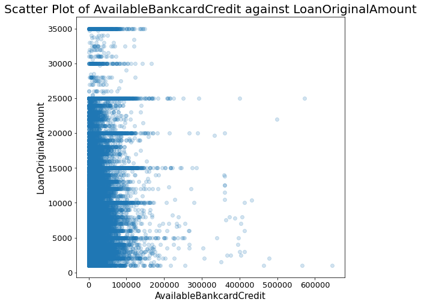

## (Visualization 7)

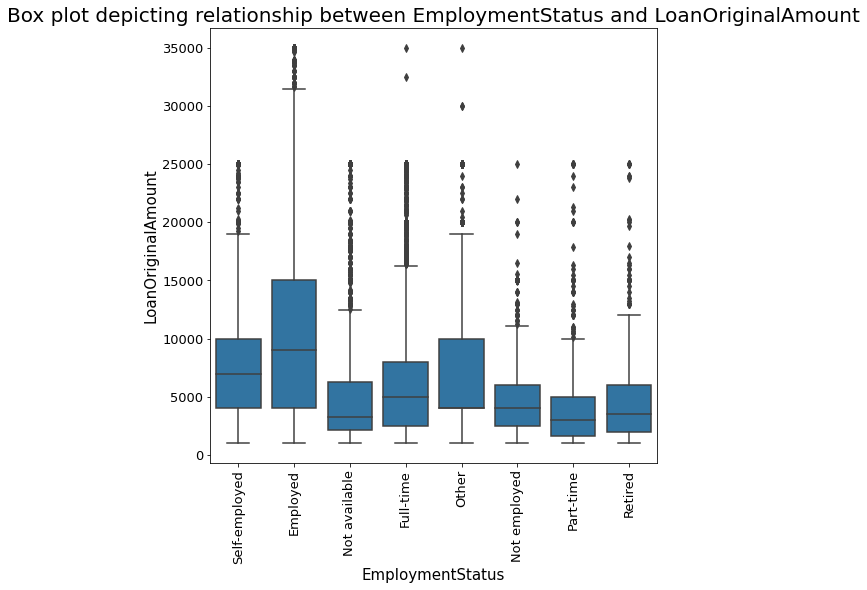

## (Visualization 8)

> - Most loan amounts above `25,000` were issued to borrowers in the largest income-range category of `100,000+`.

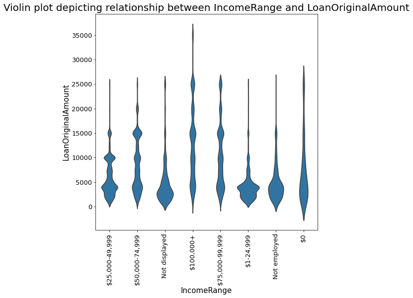

## (Visualization 9)

> - Borrowers of loans above `25,000` are in the `7`, `6` and `5` of ProsperRating (numeric) categories.

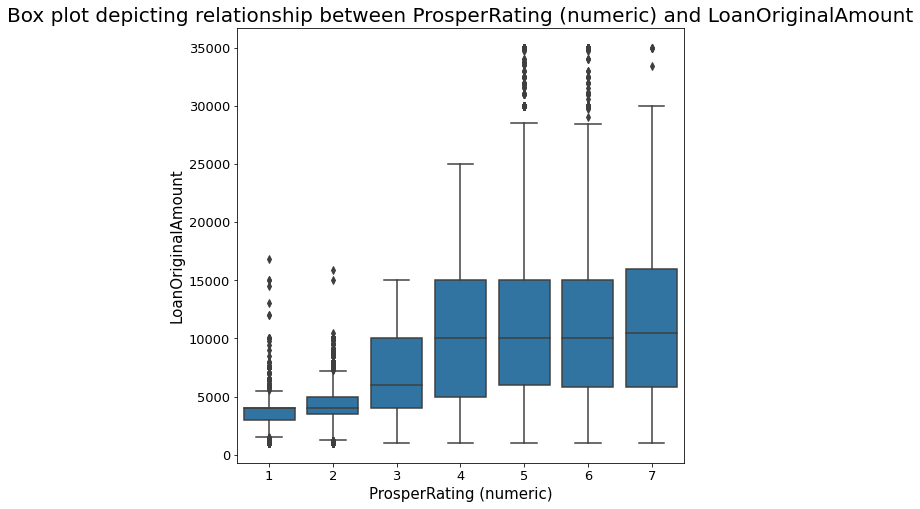